# 커피의 열역학

추출 온도 × 생산성 — 92°C에서 최적 추출, 인간에게도 최적 온도가 있는가?

Author

Insight Lab × Chimera AI

Published

May 22, 2026

## 1 들어가며: 한 잔의 커피, 하나의 열역학 시스템

> *“커피 한 잔에는 우주가 들어 있다.”* — 에두아르도 갈레아노

매일 아침 우리는 무심코 열역학 실험을 수행한다. 90~96°C의 물이 분쇄된 커피 입자를 만나 **1,000종 이상의 화학 물질**을 선택적으로 용해시키는 과정—이것이 커피 추출이다. 그런데 놀라운 사실이 있다. 커피의 최적 추출 온도(~92°C)와 인간의 최적 인지 수행 온도(~22°C)는 완전히 다른 스케일이지만, 둘 다 **역U자 곡선**이라는 동일한 수학적 구조를 공유한다.

이 에세이는 묻는다: **“최적”이라는 개념 자체가 열역학적 필연인가?**

**크로스오버 분야**

**열역학 × 인지과학 × 생산성 심리학** 커피 추출의 물리화학, 카페인의 약동학, 인간 인지 수행의 최적 조건을 하나의 프레임워크로 통합한다.

## 2 커피 추출의 열역학: 용해의 물리학

### 2.1 추출은 엔트로피 증가 과정이다

커피 추출의 본질은 **고체(커피 입자) → 액체(물)**로의 물질 이동이다. 열역학 제2법칙에 따라 이 과정은 전체 엔트로피를 증가시키는 방향, 즉 자발적으로 진행된다. 깁스 자유에너지로 표현하면:

$$\Delta G = \Delta H - T \Delta S < 0$$

- **$\Delta H$** (엔탈피 변화): 용해는 대부분 흡열 반응. 에너지 투입이 필요하다.
- **$T \Delta S$** (엔트로피 기여): 온도가 높을수록 엔트로피 항이 지배적이 되어 $\Delta G < 0$이 쉽게 달성된다.

이것이 **뜨거운 물이 더 많은 성분을 추출하는 근본 이유**다.

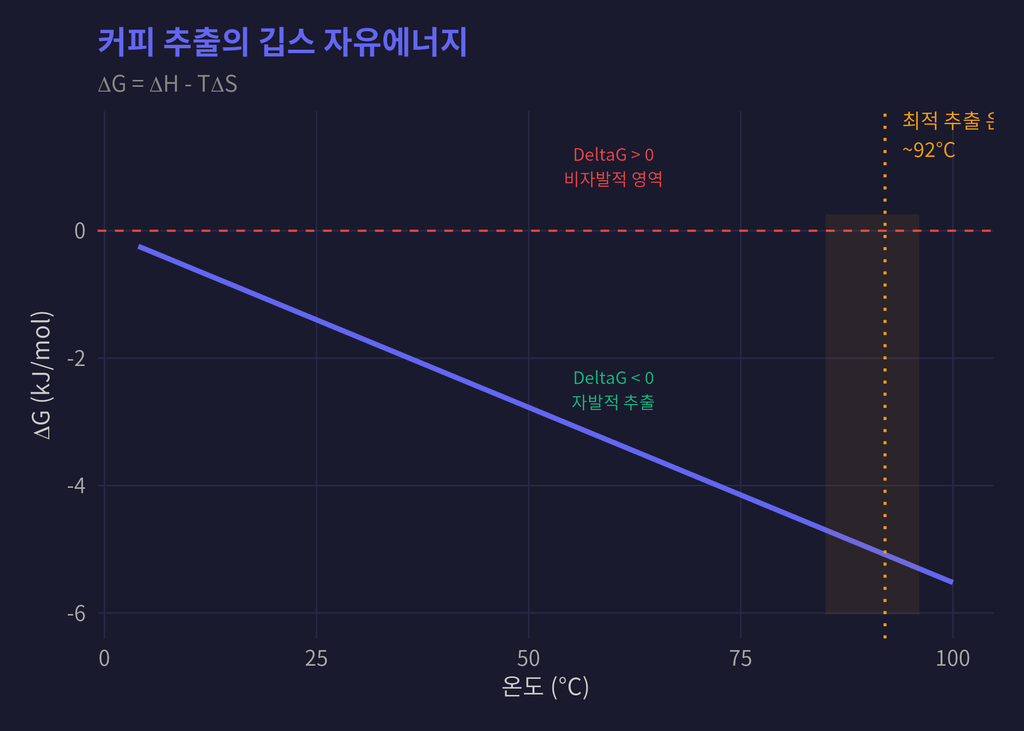

Figure 1: 온도에 따른 깁스 자유에너지 변화 — 온도가 높을수록 추출이 자발적으로 진행된다

### 2.2 아레니우스 방정식: 온도와 추출 속도

추출 **속도**는 아레니우스 방정식을 따른다:

$$k = A \cdot e^{-E_a / RT}$$

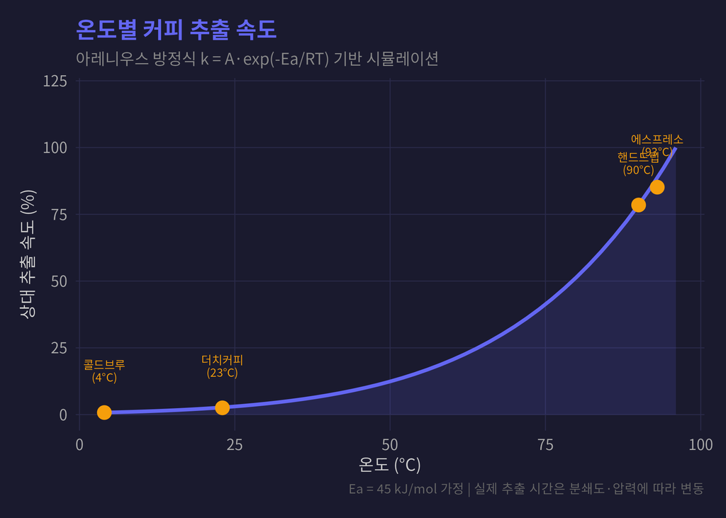

Figure 2: 아레니우스 모델 기반 온도별 커피 추출 속도 상수

### 2.3 추출 수율의 황금 구간: 18~22%

커피의 총 가용 성분 중 실제로 추출되는 비율을 **추출 수율(Extraction Yield, EY)**이라 한다. Specialty Coffee Association(SCA)이 정의한 이상적 추출 수율은 **18~22%**다.

Table 1: 추출 수율 구간별 맛 프로파일

[output not shown]

**핵심 통찰 #1**

커피 추출의 최적 구간은 **“충분히 뜨겁지만 너무 뜨겁지 않은”** 좁은 온도 범위에 존재한다. 이 역U자 패턴은 열역학의 필연이다—엔트로피가 충분히 커야 추출이 진행되지만, 과잉 에너지는 원치 않는 분해 반응을 촉발한다.

## 3 카페인의 약동학: 분자 수준의 에너지 전쟁

### 3.1 아데노신 vs 카페인: 수용체 점령전

뇌에서 **아데노신(adenosine)**은 “피로 신호”를 전달하는 신경조절물질이다. 각성 상태가 지속되면 아데노신이 축적되어 A₁·A₂ₐ 수용체에 결합하고, 뉴런의 활성을 억제한다—이것이 졸음이다.

**카페인**은 아데노신과 분자 구조가 유사하여 같은 수용체에 경쟁적으로 결합한다. 그러나 카페인은 억제 신호를 보내지 않는다—빈 의자를 차지하고 앉아 아무 것도 하지 않는 것이다. 결과적으로 아데노신의 졸음 신호가 차단된다.

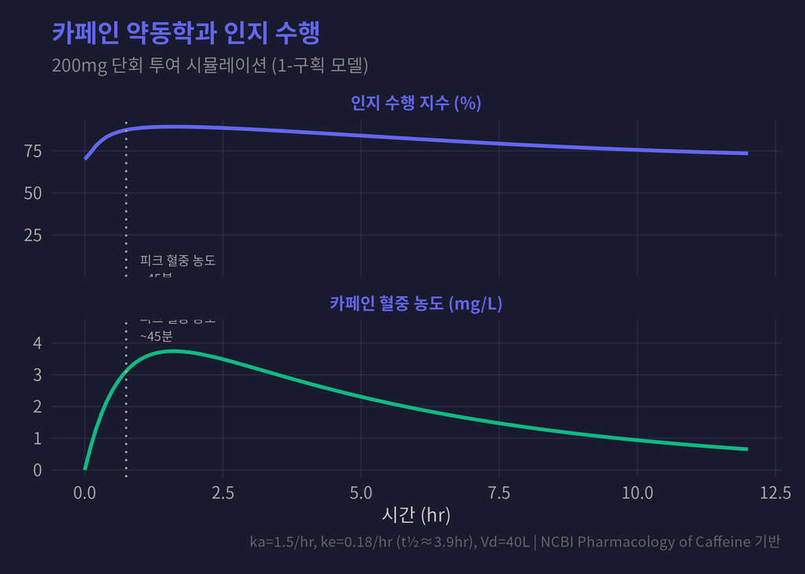

Figure 3: 카페인 혈중 농도 변화와 인지 수행 영향 (200mg 단회 투여)

### 3.2 용량-반응 곡선: 역U자의 재등장

카페인의 인지 증강 효과도 커피 추출과 동일한 **역U자 곡선**을 따른다.

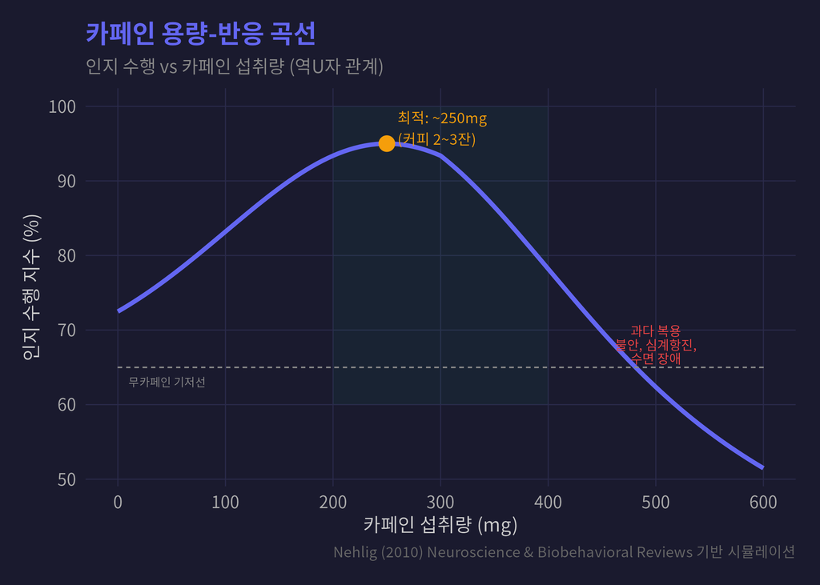

Figure 4: 카페인 용량-반응 곡선: 인지 수행의 역U자 패턴

## 4 인간의 최적 온도: Yerkes-Dodson의 열역학

### 4.1 22°C의 비밀

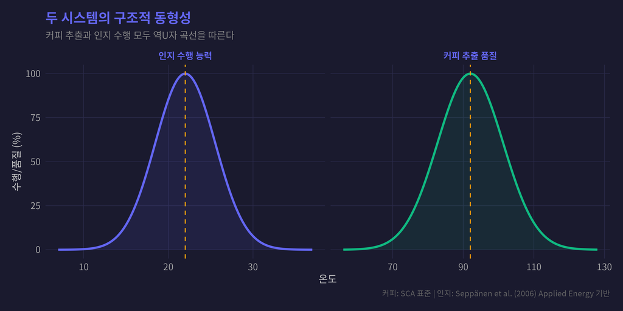

Figure 5: Yerkes-Dodson 법칙과 커피 추출의 구조적 동형성

### 4.2 왜 역U자인가? — 열역학적 필연

이 패턴의 근본 원인은 **두 가지 상반된 프로세스의 경쟁**이다:

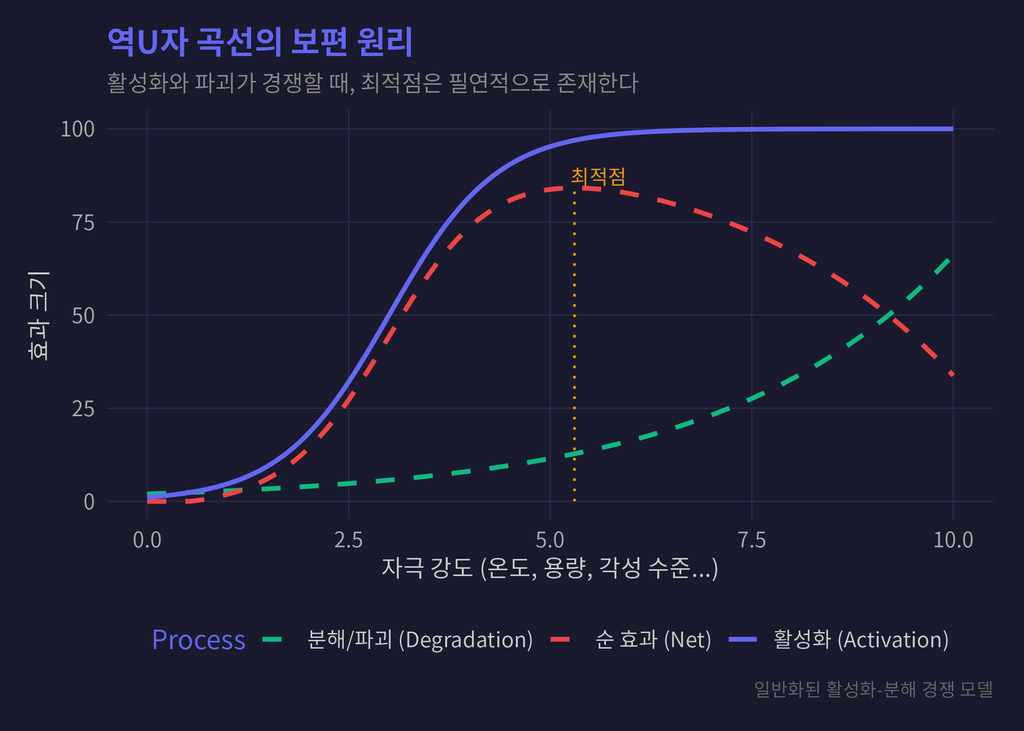

Figure 6: 역U자 곡선의 열역학적 기원: 활성화 vs 파괴의 경쟁

Table 2: 세 시스템의 역U자 구조 비교

[output not shown]

## 5 시뮬레이션: 하루의 열역학

### 5.1 직장인의 카페인-생산성 궤적

전형적인 직장인의 하루를 시뮬레이션해보자. 오전 8시 첫 커피, 오후 2시 두 번째 커피. 카페인의 반감기(3.9시간)와 아데노신 축적을 함께 모델링한다.

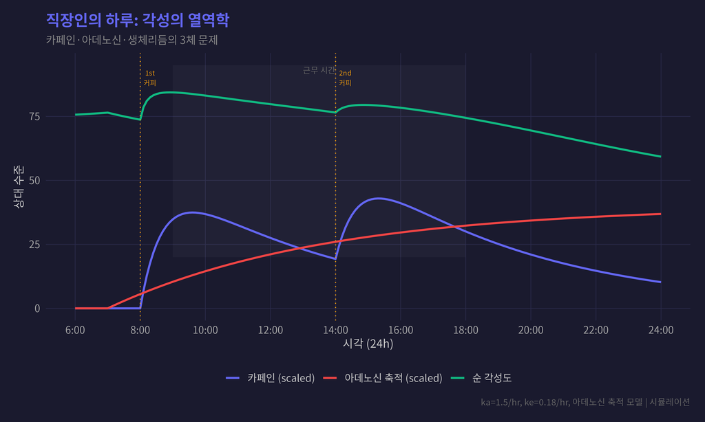

Figure 7: 직장인의 하루: 카페인 혈중 농도와 생산성 시뮬레이션

## 6 통합 모델: 최적의 보편 법칙

### 6.1 모든 역U자 곡선의 수학적 통일

커피 추출, 카페인 효과, 인지 수행, Yerkes-Dodson 법칙—이들의 공통 구조를 하나의 수학적 프레임워크로 표현할 수 있다:

$$P(x) = P_{\max} \cdot \exp\left(-\frac{(x - x^*)^2}{2\sigma^2}\right)$$

여기서 $x^*$는 최적점, $\sigma$는 허용 범위(강건성), $P_{\max}$는 최대 수행이다.

이 모델이 시사하는 것은 **최적점의 존재는 보편적**이지만, **최적점의 위치와 허용 범위는 시스템마다 다르다**는 것이다.

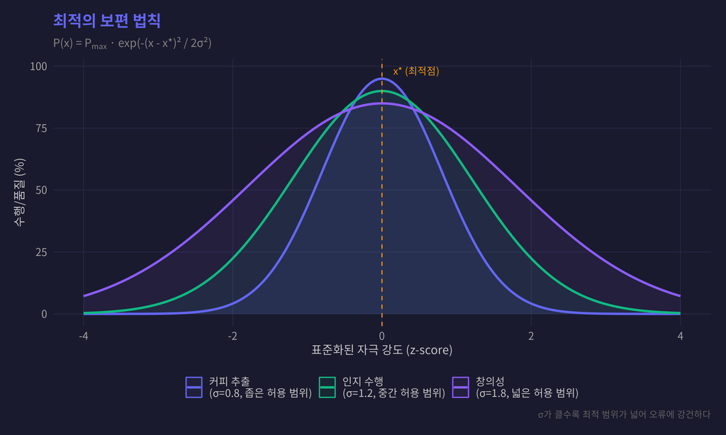

Figure 8: 최적의 보편 법칙: 다양한 시스템의 역U자 곡선 통합

### 6.2 강건성(σ)의 의미

**핵심 통찰 #2: 최적은 하나가 아니다**

열역학이 가르치는 교훈: **최적점(x*)은 시스템마다 다르지만, 최적점이 존재한다는 사실 자체는 보편적이다.** 활성화와 분해가 경쟁하는 모든 시스템에서 역U자 곡선은 필연적으로 나타난다. 커피 한 잔이 이 우주적 진리를 매일 아침 증명한다.

## 7 실용적 시사점: 최적 커피 전략

Table 3: 열역학 기반 최적 커피 전략

[output not shown]

## 8 결론: 92°C와 22°C 사이의 우주

커피 한 잔은 열역학의 축소판이다. 물 분자의 운동 에너지가 커피 입자의 세포벽을 뚫고 향기 물질을 끌어내는 과정은, 본질적으로 **엔트로피가 질서를 창조하는 순간**이다. 그리고 그 커피가 우리의 뇌에서 아데노신 수용체를 점령하여 각성을 유지시키는 과정 역시, 분자 수준의 에너지 전쟁이다.

이 두 과정이 공유하는 **역U자 곡선**은 우연의 일치가 아니다. 활성화와 분해가 경쟁하는 **모든** 시스템에서 최적점은 필연적으로 존재한다. 이것은 커피의 법칙이자, 인지의 법칙이자, 삶의 법칙이다.

> *“충분히, 그러나 너무 많지 않게.”*

이것이 92°C의 물과 22°C의 사무실이 우리에게 가르치는 동일한 교훈이다.

**참고 문헌**

1. Batali, M. E. et al. (2020). “Brew temperature, at fixed brew strength and extraction, has little impact on the sensory profile of drip brew coffee.” *Scientific Reports*, 10, 16450. [Nature](https://www.nature.com/articles/s41598-020-73341-4)
2. Seppänen, O. et al. (2006). “Effects of moderate thermal environments on cognitive performance: A multidisciplinary review.” *Applied Energy*, 236, 760-777. [ScienceDirect](https://www.sciencedirect.com/science/article/abs/pii/S0306261918318233)
3. Nehlig, A. (2010). “Is caffeine a cognitive enhancer?” *Journal of Alzheimer’s Disease*, 20(S1), S85-S94.
4. Moroney, K. M. et al. (2019). “An equilibrium desorption model for the strength and extraction yield of full immersion brewed coffee.” *Scientific Reports*, 11, 7025. [PMC](https://pmc.ncbi.nlm.nih.gov/articles/PMC7994670/)
5. Yerkes, R. M. & Dodson, J. D. (1908). “The relation of strength of stimulus to rapidity of habit-formation.” *Journal of Comparative Neurology and Psychology*, 18(5), 459-482.
6. Institute of Medicine (2001). “Pharmacology of Caffeine.” *Caffeine for the Sustainment of Mental Task Performance*. National Academies Press. [NCBI](https://www.ncbi.nlm.nih.gov/books/NBK223808/)
7. Chang, D. et al. (2020). “Cognition and Brain Activation in Response to Various Doses of Caffeine.” *Frontiers in Human Neuroscience*, 14, 246. [PMC](https://www.ncbi.nlm.nih.gov/pmc/articles/PMC7350703/)

*Insight Lab E1 — 일상의 과학 시리즈 첫 번째 보고서* *열역학 × 인지과학 × 생산성 심리학*